# Taller 7

Métodos Computacionales para Políticas Públicas - URosario

**Entrega: viernes 11-oct-2019 11:59 PM**

**Juan Camilo Salgado Ramírez**  
juanca.salgado@urosario.edu.co

## Instrucciones:

- Guarde una copia de este *Jupyter Notebook* en su computador, idealmente en una carpeta destinada al material del curso.
- Modifique el nombre del archivo del *notebook*, agregando al final un guión inferior y su nombre y apellido, separados estos últimos por otro guión inferior. Por ejemplo, mi *notebook* se llamaría: mcpp_taller7_santiago_matallana
- Marque el *notebook* con su nombre y e-mail en el bloque verde arriba. Reemplace el texto "[Su nombre acá]" con su nombre y apellido. Similar para su e-mail.
- Desarrolle la totalidad del taller sobre este *notebook*, insertando las celdas que sea necesario debajo de cada pregunta. Haga buen uso de las celdas para código y de las celdas tipo *markdown* según el caso.
- Recuerde salvar periódicamente sus avances.
- Cuando termine el taller:
  1. Descárguelo en PDF. Si tiene algún problema con la conversión, descárguelo en HTML.
  2. Suba todos los archivos a su repositorio en GitHub, en una carpeta destinada exclusivamente para este taller, antes de la fecha y hora límites.

(Todos los ejercicios tienen el mismo valor.)

Este taller tiene dos partes. Una obligatoria, relativamente fácil, y otra voluntaria y más retadora. Los invito a intentar desarrollar el taller en su totalidad.

En este taller exploraremos los datos de crimen de Chicago.

Descargue los datos de crimen del Chicago Data Portal solo para el año 2015 (https://data.cityofchicago.org/Public-Safety/Crimes-2001-to-present/ijzp-q8t2/data).

### 1.

Calcule el número de crímenes en cada Community Area en 2015. Haga un gráfico de barras que lo ilustre.

```python
import pandas as pd
import numpy as np
import matplotlib.pyplot as plt
%matplotlib inline

plt.rcParams["figure.figsize"] = [38.0, 20.0]


# ---> Leer base de datos:

base_2015 = pd.read_csv('Crimes_2015.csv', parse_dates=['Date'])
base_2015.head()
```

|  | ID | Case Number | Date | Block | IUCR | Primary Type | Description | Location Description | Arrest | Domestic | ... | Ward | Community Area | FBI Code | X Coordinate | Y Coordinate | Year | Updated On | Latitude | Longitude | Location |
| --- | --- | --- | --- | --- | --- | --- | --- | --- | --- | --- | --- | --- | --- | --- | --- | --- | --- | --- | --- | --- | --- |
| 0 | 10445881 | HZ184633 | 2015-12-31 | 060XX S HALSTED ST | 1185 | DECEPTIVE PRACTICE | DECEPTIVE COLLECTION PRACTICES | APARTMENT | False | False | ... | 16.0 | 68 | 11 | NaN | NaN | 2015 | 02/09/2018 03:44:29 PM | NaN | NaN | NaN |
| 1 | 10371800 | HZ106801 | 2015-12-31 | 019XX N Hoyne Ave | 1153 | DECEPTIVE PRACTICE | FINANCIAL IDENTITY THEFT OVER $ 300 | NaN | False | False | ... | 32.0 | 22 | 11 | 1162044.0 | 1913082.0 | 2015 | 02/10/2018 03:50:01 PM | 41.917165 | -87.680077 | (41.917165184, -87.680076699) |
| 2 | 10369351 | HZ105321 | 2015-12-31 | 0000X W RANDOLPH ST | 1150 | DECEPTIVE PRACTICE | CREDIT CARD FRAUD | OTHER | False | False | ... | 42.0 | 32 | 11 | 1176135.0 | 1901285.0 | 2015 | 02/10/2018 03:50:01 PM | 41.884487 | -87.628663 | (41.884487451, -87.628662734) |
| 3 | 10365050 | HZ100594 | 2015-12-31 | 038XX N FREMONT ST | 0890 | THEFT | FROM BUILDING | RESIDENCE PORCH/HALLWAY | False | False | ... | 46.0 | 6 | 06 | 1169575.0 | 1925758.0 | 2015 | 02/10/2018 03:50:01 PM | 41.951788 | -87.652038 | (41.951787958, -87.652037805) |
| 4 | 10364402 | HY556328 | 2015-12-31 | 051XX S BLACKSTONE AVE | 0810 | THEFT | OVER $500 | STREET | False | False | ... | 4.0 | 41 | 06 | 1186787.0 | 1871326.0 | 2015 | 02/10/2018 03:50:01 PM | 41.802032 | -87.590499 | (41.802031713, -87.59049938) |

5 rows × 22 columns

```python
# ---> Agrupar por 'Community Area':

base_com_area = base_2015.groupby("Community Area")
```

```python
# ---> Calcular total de ocurrencias en la base x 'Community Area':

com_area_count = base_com_area['ID'].agg('count').to_frame()
com_area_count.rename(columns = {'ID':'Ocurrencia crimenes'}, inplace = True)

    # Ordenando la base segun ocurrencias de crimen:
com_area_count = com_area_count.sort_values('Ocurrencia crimenes', ascending = False)
com_area_count.head()
```

| Community Area | Ocurrencia crimenes |
| --- | --- |
| 25 | 17367 |
| 43 | 9076 |
| 8 | 9050 |
| 29 | 8407 |
| 23 | 8194 |

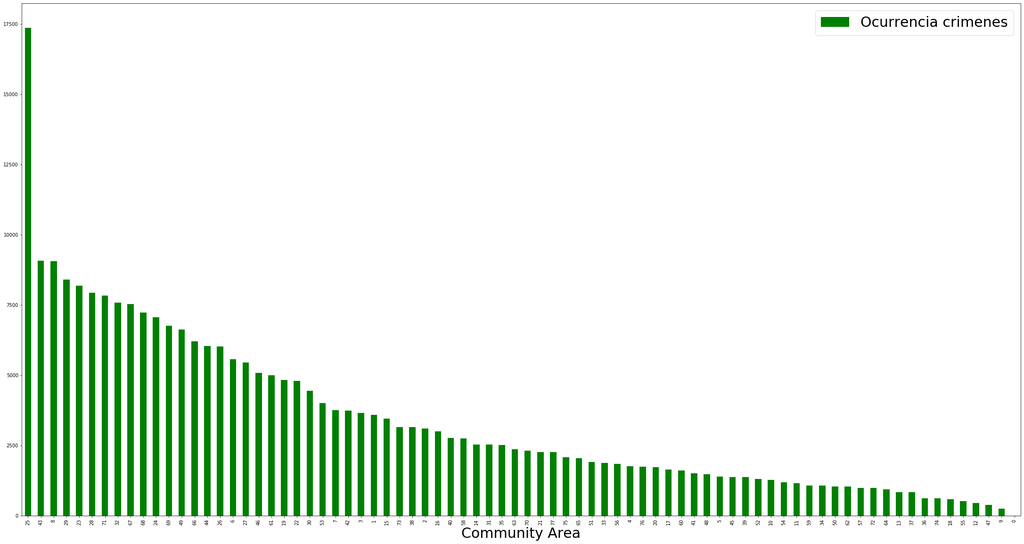

```python
# ---> Graficar:

plt.rcParams["figure.figsize"] = [38.0, 20.0]

com_area_count.plot(kind='bar', color='green')
plt.xlabel('Community Area', fontsize = 30)
plt.legend(loc = 0, prop={'size': 30});
```

### 2.

Ordene las Community Areas de acuerdo con el número de crímenes. ¿Qué Community Area (por nombre, idealmente) presenta el mayor número de crímenes? ¿El menor?

```python
# ---> 'Community Area' con mas crimenes:

    ### (Ya habia ordenado la base previamente, para graficar).

    ### En la base de datos no esta el nombre de cada 'Community Area'. Buscando en internet encontre que
    ### el nombre de la 'Community Area' con mas crimenes (la # 25) es Austin. La de menor numero de crimenes
    ### es la numero 0. Sin embargo no aparece el nombre de esta (probablemente corresponde a un error). Por lo
    ### tanto, la 'Community Area' con menos crimenes no es la que corresponde al numero '0' sino al siguiente, que
    ### es '9'. El nombre de esta 'Community Area' es 'Edison Park'.

print('\nCommunity Area con mas crimenes: Austin\n')
print(com_area_count.loc[com_area_count['Ocurrencia crimenes'].idxmax()])

# ---> 'Community Area' con menos crimenes (asumiendo que la de codigo '0' es un error):

print('\nCommunity Area con menos crimenes: Edison Park ')
com_area_count_no_cero = com_area_count.drop(0)
com_area_count_no_cero.loc[com_area_count_no_cero['Ocurrencia crimenes'].idxmin()]
```

```
Community Area con mas crimenes: Austin

Ocurrencia crimenes    17367
Name: 25, dtype: int64

Community Area con menos crimenes: Edison Park
```

```
Ocurrencia crimenes    258
Name: 9, dtype: int64
```

### 3.

Cree una tabla cuyas filas sean días del año (yyyy-mm-dd) y las columnas las 77 Community Areas. En cada campo de la tabla deberá haber el correspondiente número de crímenes. Seleccione algunas Community Areas que le llamen la atención y haga un gráfico de serie de tiempo.

Pista: El siguiente código puede serle útil.

```python
# Create function to strip time from date field, and use it to create another column
def to_day(timestamp):
    return timestamp.replace(minute=0,hour=0, second=0)

base_2015['Day'] = base_2015['Date'].apply(to_day)
```

```python
# ---> Agrupar por 'Community Area' y 'Date':

com_area_day = base_2015.groupby(['Community Area', 'Day'])

# ---> Totalizar por grupo:

com_area_count_day = com_area_day['ID'].agg('count').to_frame()
```

```python
# ---> Crear tabla con frecuencias diarias:

tabla_dias = pd.DataFrame({'Fecha': pd.date_range(start = '2015-01-01', end = '2015-12-31')})

# ---> Lista de 'Community Areas':

base_2015.rename(columns = {'Community Area':'Community_Area'}, inplace = True)

com_list = base_2015.Community_Area.unique()

# ---> Loop para llenar la tabla, para cada 'Community Area':

for com in com_list:

    for date in tabla_dias.Fecha:

        # try: si encuentra la fecha en la ocurrencia de crimenes
        try:

            asignar = com_area_count_day.loc[com].loc[date]['ID']
            tabla_dias.loc[tabla_dias.Fecha == date, com] = asignar

        # except: no encuentra la fecha en la ocurrencia de crimenes, asigna 'cero'
        except:

            asignar = 0
            tabla_dias.loc[tabla_dias.Fecha == date, com] = asignar

tabla_dias.head()
```

|  | Fecha | 68 | 22 | 32 | 6 | 41 | 14 | 25 | 33 | 71 | ... | 51 | 17 | 60 | 57 | 12 | 52 | 59 | 47 | 34 | 0 |
| --- | --- | --- | --- | --- | --- | --- | --- | --- | --- | --- | --- | --- | --- | --- | --- | --- | --- | --- | --- | --- | --- |
| 0 | 2015-01-01 | 31.0 | 32.0 | 14.0 | 25.0 | 6.0 | 7.0 | 94.0 | 12.0 | 53.0 | ... | 9.0 | 7.0 | 15.0 | 3.0 | 1.0 | 13.0 | 0.0 | 2.0 | 6.0 | 0.0 |
| 1 | 2015-01-02 | 12.0 | 21.0 | 11.0 | 10.0 | 7.0 | 2.0 | 54.0 | 4.0 | 17.0 | ... | 3.0 | 3.0 | 4.0 | 6.0 | 1.0 | 2.0 | 1.0 | 1.0 | 1.0 | 0.0 |
| 2 | 2015-01-03 | 23.0 | 14.0 | 7.0 | 6.0 | 4.0 | 6.0 | 55.0 | 4.0 | 18.0 | ... | 2.0 | 7.0 | 4.0 | 4.0 | 1.0 | 3.0 | 3.0 | 0.0 | 2.0 | 0.0 |
| 3 | 2015-01-04 | 13.0 | 13.0 | 10.0 | 15.0 | 3.0 | 4.0 | 33.0 | 6.0 | 12.0 | ... | 4.0 | 0.0 | 4.0 | 2.0 | 0.0 | 2.0 | 3.0 | 0.0 | 4.0 | 0.0 |
| 4 | 2015-01-05 | 16.0 | 6.0 | 20.0 | 15.0 | 0.0 | 8.0 | 36.0 | 7.0 | 17.0 | ... | 4.0 | 2.0 | 1.0 | 1.0 | 0.0 | 3.0 | 1.0 | 2.0 | 3.0 | 0.0 |

5 rows × 79 columns

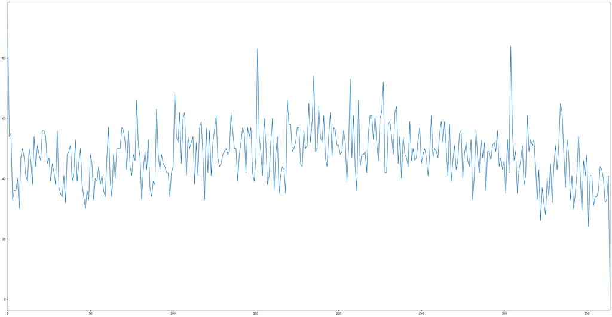

```python
# ---> Graficar las 'Community Areas' con mayor/menor ocurrencia total de crimenes:

# ---> Mayor ocurrencia (#25):

tabla_dias[25].plot()
```

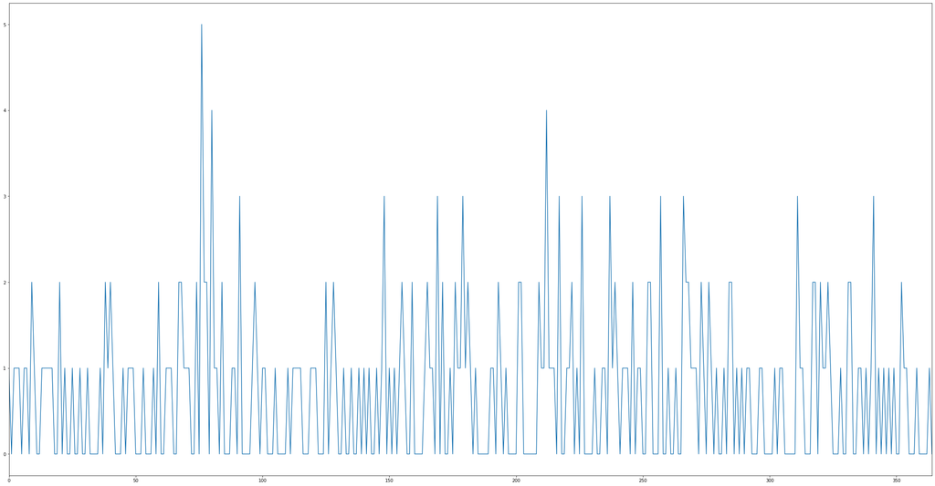

```python
# ---> Menor ocurrencia (#9):

tabla_dias[9].plot()
```

### Parte voluntaria

Descargue la base de datos de información socioeconómica (https://data.cityofchicago.org/Health-Human-Services/Census-Data-Selected-socioeconomic-indicators-in-C/kn9c-c2s2).

### 4.

Cree una tabla que agregue el número de crímenes por Community Area. Una esa tabla con la de datos socioeconómicos y cree un "scatter plot" de número de crímenes vs ingreso per cápita. Explique la relación en palabras.